# Labor Market Unemployment Trends Analysis

# Seasonal Patterns

## Does Unemployment Follow a Seasonal Rhythm?

Labor markets have natural seasonal cycles — construction slows in winter, retail spikes during holidays. The chart below shows how unemployment rates behave across months, split by economic era.

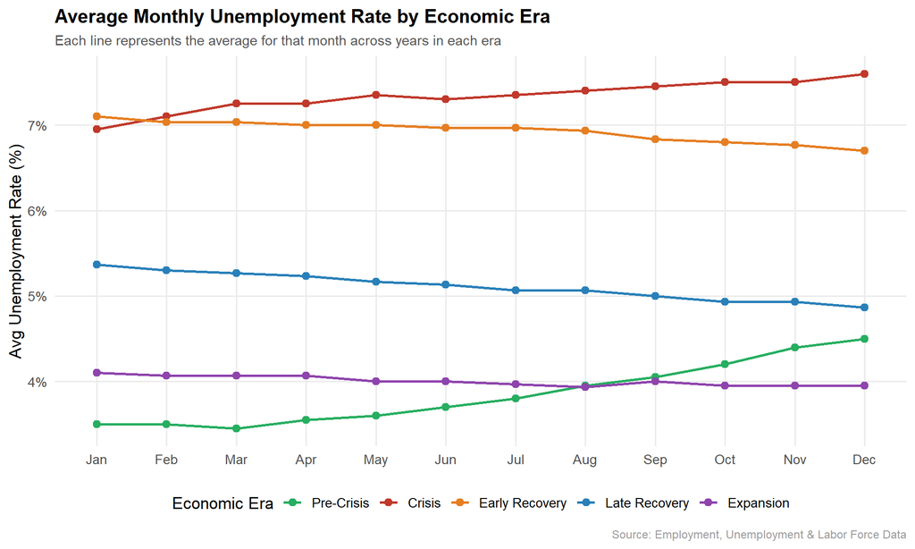

```r
seasonal <- df %>%
  group_by(Month, Era) %>%
  summarise(Avg_Rate = mean(`Unemployment Rate`), .groups="drop") %>%
  mutate(MonthLabel = factor(month.abb[Month], levels = month.abb))

ggplot(seasonal, aes(x = MonthLabel, y = Avg_Rate,
                     group = Era, color = Era)) +
  geom_line(linewidth = 1.0) +
  geom_point(size = 2.5) +
  scale_color_manual(values = c(
    "Pre-Crisis"     = "#27ae60",
    "Crisis"         = "#c0392b",
    "Early Recovery" = "#e67e22",
    "Late Recovery"  = "#2980b9",
    "Expansion"      = "#8e44ad"
  )) +
  scale_y_continuous(labels = function(x) paste0(x, "%")) +
  labs(
    title    = "Average Monthly Unemployment Rate by Economic Era",
    subtitle = "Each line represents the average for that month across years in each era",
    x = NULL, y = "Avg Unemployment Rate (%)",
    color = "Economic Era",
    caption = "Source: Employment, Unemployment & Labor Force Data"
  ) +
  theme_minimal(base_size = 13) +
  theme(
    plot.title    = element_text(face="bold", size=15),
    plot.subtitle = element_text(color="#555", size=11),
    legend.position = "bottom",
    panel.grid.minor = element_blank(),
    plot.caption = element_text(color="#999", size=9)
  )
```

# Employment vs. Unemployed Persons

## The Absolute Numbers Tell a Different Story

While rates are useful, the raw numbers reveal scale. At the crisis peak, over **236,000 people** were unemployed. The number of employed persons, meanwhile, showed strong and consistent growth from 2010 onward.

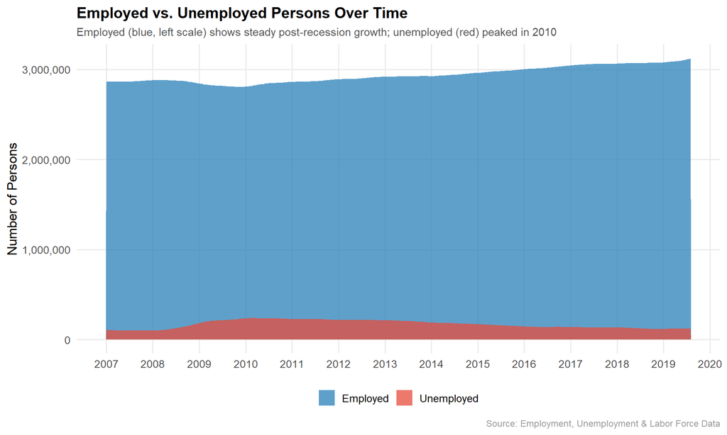

```r
df %>%
  select(Date, Employed, Unemployed) %>%
  pivot_longer(-Date, names_to = "Status", values_to = "Count") %>%
  ggplot(aes(x = Date, y = Count, fill = Status)) +
  geom_area(alpha = 0.75, position = "identity") +
  scale_fill_manual(values = c("Employed" = "#2980b9", "Unemployed" = "#e74c3c"),
                    name = NULL) +
  scale_x_date(date_breaks = "1 year", date_labels = "%Y") +
  scale_y_continuous(labels = comma) +
  labs(
    title    = "Employed vs. Unemployed Persons Over Time",
    subtitle = "Employed (blue, left scale) shows steady post-recession growth; unemployed (red) peaked in 2010",
    x = NULL, y = "Number of Persons",
    caption = "Source: Employment, Unemployment & Labor Force Data"
  ) +
  theme_minimal(base_size = 13) +
  theme(
    plot.title    = element_text(face="bold", size=15),
    plot.subtitle = element_text(color="#555", size=11),
    legend.position = "bottom",
    panel.grid.minor = element_blank(),
    plot.caption = element_text(color="#999", size=9)
  )
```